# TIG’R - Graphique R-base

## Exercice

1. Créez un projet Rstudio

*File/New Project/New Directory…*

2. Téléchargez les données suivantes :

| Intitulé | Téléchargement |
| --- | --- |
| Données pays africains (UN-CEPII) | [Download](https://bit.ly/3DaCAkX) |

3. Placez les données (décompressées) dans le répertoire de votre projet, de la façon suivante :

[figure not shown]

4. Importez le fichier “afrika_don.csv” dans un data.frame

**Un peu d’aide ?**

```r
... <- read.csv2(file = "...")
```

5. Construisez un histogramme par quartile pour la variable “POP” :

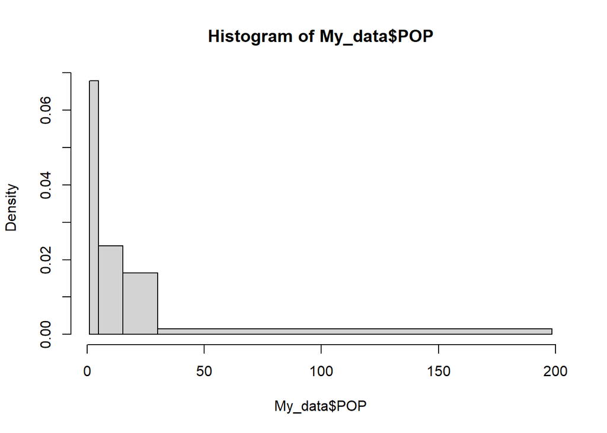

**Un peu d’aide ?**

```r
hist(..., breaks  = quantile(...))
```

6. Améliorez la mise en page, en ajoutant par exemple un peu de couleur, un titre, une source… :

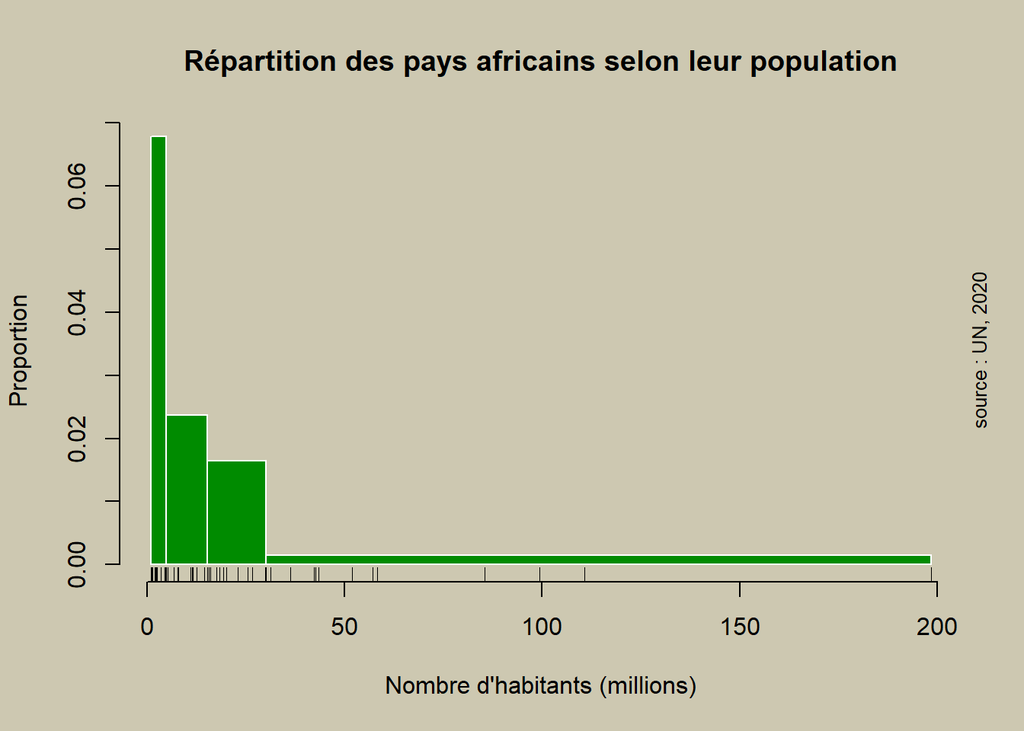

**Un exemple ?**

```r
par(bg = "cornsilk3")

hist(My_data$POP,
     breaks  = quantile(My_data$POP),
     col = "green4",
     border = "white",
     xlab = "Nombre d'habitants (millions)",
     ylab = "Proportion",
     main = "Répartition des pays africains selon leur population")

rug(My_data$POP)
mtext(side = 4, "source : UN, 2020", cex = 0.8)
```

7. Exportez le graphique à l’aide d’une fonction (format png)

**Un peu d’aide ?**

```r
dev.print(device = ..., file = "...")
```